# Evaluating Winner’s Curse methods

In this document, we intend to investigate the following key questions, assuming a fixed array of $10^6$ SNPs and a quantitative trait in which SNP effect sizes follow a *normal* distribution:

- When should I be concerned about Winner’s Curse or about my association estimates being more extreme than their corresponding true effect sizes?
- If I adjust SNP-trait association estimates using a Winner’s Curse method, how much should I expect this to improve the association estimates of significant SNPs?
- If I do use a Winner’s Curse method, which one should I use?

### 1. When is Winner’s Curse a problem?

In this section, we look at the average number of significant SNPs and the average proportion of these significant SNPs that have association estimates more extreme than their true effect size at two different thresholds; the common genome-wide significance threshold of $5 \times 10^{-8}$ and a higher threshold of $5 \times 10^{-4}$. We consider these properties under certain combinations of values for the following parameters:

1. sample size - `n_samples`
2. heritability - `h2`
3. polygenicity, i.e. proportion of effect SNPs - `prop_effect`
4. selection coefficient - `S`

The 24 different combinations that we will investigate throughout this document are detailed below:

| Scenario | n_samples | h2 | prop_effect | S |
| --- | --- | --- | --- | --- |
| 1 | 30,000 | 0.3 | 0.010 | -1 |
| 2 | 300,000 | 0.3 | 0.010 | -1 |
| 3 | 30,000 | 0.8 | 0.010 | -1 |
| 4 | 300,000 | 0.8 | 0.010 | -1 |
| 5 | 30,000 | 0.3 | 0.001 | -1 |
| 6 | 300,000 | 0.3 | 0.001 | -1 |
| 7 | 30,000 | 0.8 | 0.001 | -1 |
| 8 | 300,000 | 0.8 | 0.001 | -1 |
| 9 | 30,000 | 0.3 | 0.010 | 0 |
| 10 | 300,000 | 0.3 | 0.010 | 0 |
| 11 | 30,000 | 0.8 | 0.010 | 0 |
| 12 | 300,000 | 0.8 | 0.010 | 0 |

| Scenario | n_samples | h2 | prop_effect | S |
| --- | --- | --- | --- | --- |
| 13 | 30,000 | 0.3 | 0.001 | 0 |
| 14 | 300,000 | 0.3 | 0.001 | 0 |
| 15 | 30,000 | 0.8 | 0.001 | 0 |
| 16 | 300,000 | 0.8 | 0.001 | 0 |
| 17 | 30,000 | 0.3 | 0.010 | 1 |
| 18 | 300,000 | 0.3 | 0.010 | 1 |
| 19 | 30,000 | 0.8 | 0.010 | 1 |
| 20 | 300,000 | 0.8 | 0.010 | 1 |
| 21 | 30,000 | 0.3 | 0.001 | 1 |
| 22 | 300,000 | 0.3 | 0.001 | 1 |
| 23 | 30,000 | 0.8 | 0.001 | 1 |
| 24 | 300,000 | 0.8 | 0.001 | 1 |

$~$ $~$ $~$

Running the code provided in `nsig_prop_bias_100sim.R`, we obtain the following results:

| Scenario | n_samples | h2 | prop_effect | S | n_sig 5e-8 | sd(n_sig) 5e-8 | prop_bias 5e-8 | sd(prop_bias) 5e-8 | n_sig 5e-4 | sd(n_sig) 5e-4 | prop_bias 5e-4 | sd(prop_bias) 5e-4 |
| --- | --- | --- | --- | --- | --- | --- | --- | --- | --- | --- | --- | --- |
| 1 | 30,000 | 0.3 | 0.010 | -1 | 0.70 | 0.745 | 0.5600 | 0.4989 | 610.55 | 24.819 | 0.9996 | 0.0008 |
| 2 | 300,000 | 0.3 | 0.010 | -1 | 848.63 | 18.145 | 0.7606 | 0.0142 | 3202.84 | 39.990 | 0.7461 | 0.0070 |
| 3 | 30,000 | 0.8 | 0.010 | -1 | 31.85 | 5.208 | 0.9796 | 0.0232 | 1084.25 | 34.857 | 0.9597 | 0.0053 |
| 4 | 300,000 | 0.8 | 0.010 | -1 | 2760.68 | 30.091 | 0.6283 | 0.0085 | 5354.55 | 49.606 | 0.6393 | 0.0069 |
| 5 | 30,000 | 0.3 | 0.001 | -1 | 86.90 | 6.317 | 0.7524 | 0.0466 | 767.58 | 24.228 | 0.8957 | 0.0090 |
| 6 | 300,000 | 0.3 | 0.001 | -1 | 568.70 | 14.074 | 0.5520 | 0.0197 | 1215.12 | 28.204 | 0.7303 | 0.0128 |
| 7 | 30,000 | 0.8 | 0.001 | -1 | 276.26 | 10.413 | 0.6209 | 0.0286 | 985.80 | 24.088 | 0.8043 | 0.0117 |
| 8 | 300,000 | 0.8 | 0.001 | -1 | 727.10 | 12.491 | 0.5289 | 0.0175 | 1323.99 | 25.015 | 0.7068 | 0.0127 |
| 9 | 30,000 | 0.3 | 0.010 | 0 | 1.45 | 1.298 | 0.7400 | 0.4408 | 622.70 | 20.047 | 0.9985 | 0.0015 |
| 10 | 300,000 | 0.3 | 0.010 | 0 | 882.45 | 18.435 | 0.7256 | 0.0144 | 3053.36 | 41.345 | 0.7427 | 0.0070 |
| 11 | 30,000 | 0.8 | 0.010 | 0 | 48.06 | 6.350 | 0.9524 | 0.0305 | 1113.04 | 27.657 | 0.9407 | 0.0068 |
| 12 | 300,000 | 0.8 | 0.010 | 0 | 2586.78 | 32.771 | 0.6201 | 0.0080 | 5021.84 | 49.899 | 0.6455 | 0.0062 |
| 13 | 30,000 | 0.3 | 0.001 | 0 | 88.32 | 6.377 | 0.7278 | 0.0435 | 752.65 | 23.238 | 0.8953 | 0.0097 |
| 14 | 300,000 | 0.3 | 0.001 | 0 | 531.27 | 12.431 | 0.5553 | 0.0239 | 1177.90 | 26.600 | 0.7402 | 0.0121 |
| 15 | 30,000 | 0.8 | 0.001 | 0 | 257.44 | 8.936 | 0.6212 | 0.0265 | 950.39 | 26.269 | 0.8130 | 0.0100 |
| 16 | 300,000 | 0.8 | 0.001 | 0 | 691.46 | 13.526 | 0.5322 | 0.0194 | 1299.19 | 25.483 | 0.7114 | 0.0110 |
| 17 | 30,000 | 0.3 | 0.010 | 1 | 2.55 | 1.623 | 0.9400 | 0.2387 | 639.02 | 23.892 | 0.9966 | 0.0022 |
| 18 | 300,000 | 0.3 | 0.010 | 1 | 919.28 | 15.799 | 0.7038 | 0.0137 | 2910.10 | 40.332 | 0.7313 | 0.0086 |
| 19 | 30,000 | 0.8 | 0.010 | 1 | 68.13 | 7.795 | 0.9215 | 0.0277 | 1148.44 | 26.520 | 0.9208 | 0.0077 |
| 20 | 300,000 | 0.8 | 0.010 | 1 | 2433.27 | 30.705 | 0.6097 | 0.0104 | 4630.19 | 49.334 | 0.6464 | 0.0078 |
| 21 | 30,000 | 0.3 | 0.001 | 1 | 93.15 | 5.960 | 0.7145 | 0.0422 | 739.81 | 26.383 | 0.8944 | 0.0102 |
| 22 | 300,000 | 0.3 | 0.001 | 1 | 482.94 | 12.742 | 0.5519 | 0.0194 | 1120.17 | 26.197 | 0.7510 | 0.0116 |
| 23 | 30,000 | 0.8 | 0.001 | 1 | 244.29 | 9.237 | 0.6119 | 0.0315 | 909.17 | 24.092 | 0.8199 | 0.0110 |
| 24 | 300,000 | 0.8 | 0.001 | 1 | 632.74 | 14.730 | 0.5330 | 0.0193 | 1237.86 | 25.797 | 0.7201 | 0.0121 |

For both thresholds, we note that the average number of significant SNPs increases as sample size increases, as expected. It also increases with heritability. However, the effect of changing `prop_effect` is more interesting. Decreasing the proportion of effect SNPs from 0.01 to 0.001 results in the number of significant SNPs increasing for a sample size of 30,000 while we witness the number of SNPs passing the genome-wide significance threshold decreasing for a larger sample size of 300,000.

Furthermore, increasing sample size and increasing heritability from 0.3 to 0.8 all tend to decrease the fraction of significant SNPs whose estimates are more extreme than their true effect size. Decreasing polygenicity from 0.01 to 0.001 also has this same effect at a significance threshold of $5 \times 10^{-8}$.

In order to gain a better insight into the information detailed in the above table, we simulate a single set of GWAS summary statistics and plot $z$ vs $\text{bias}$ in which $\text{bias} = \hat\beta - \beta$ for each of the 24 different scenarios. On all figures, the bright red line corresponds to the significance threshold of $5 \times 10^{-8}$ while the darker red line relates to $5 \times 10^{-4}$.

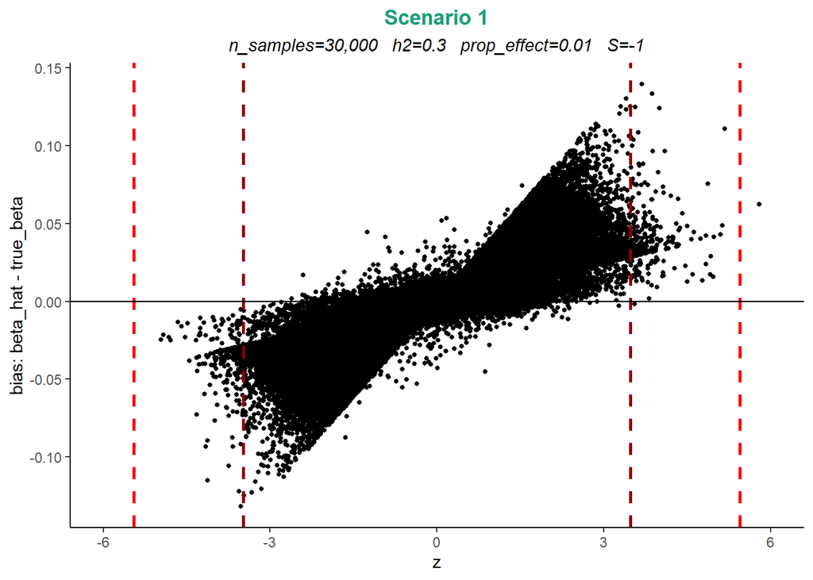

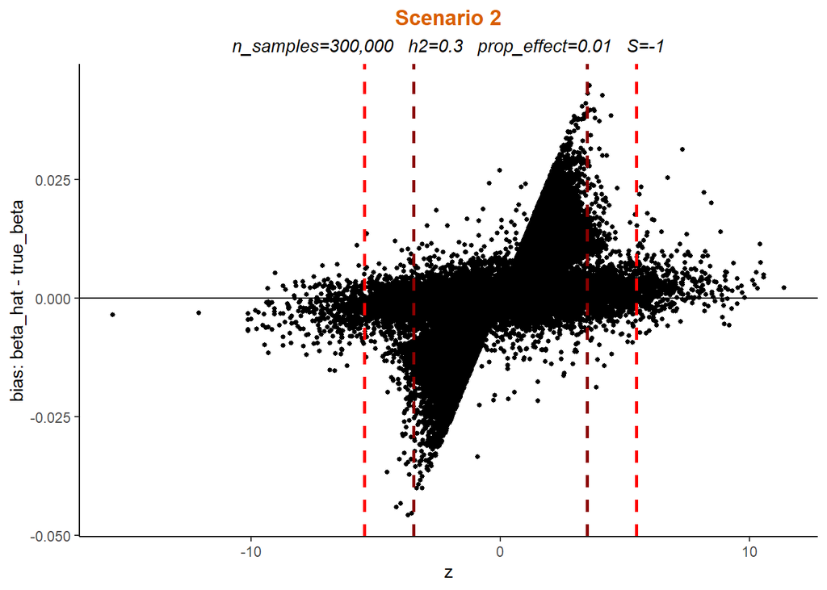

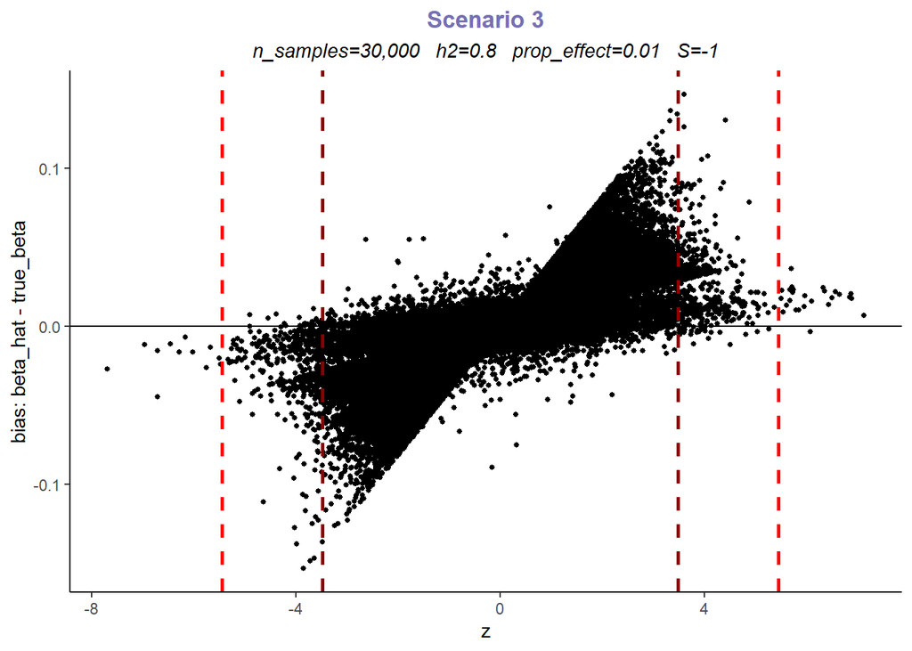

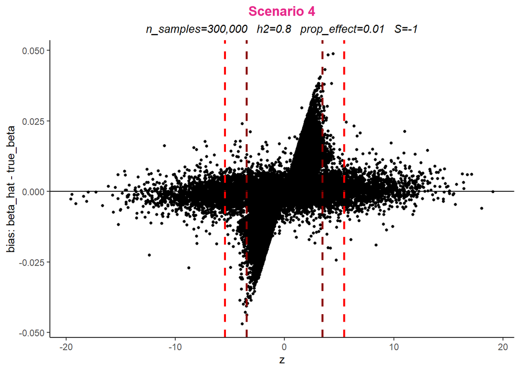

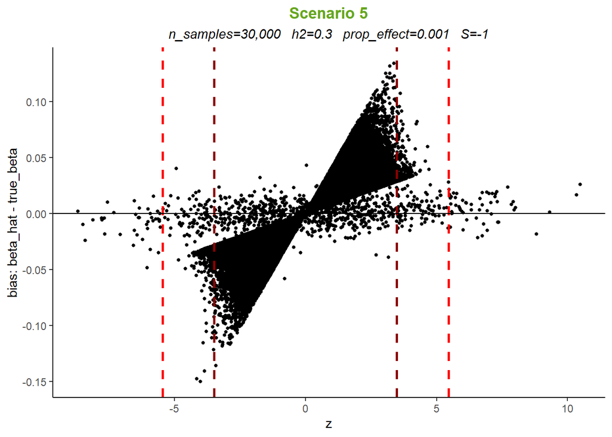

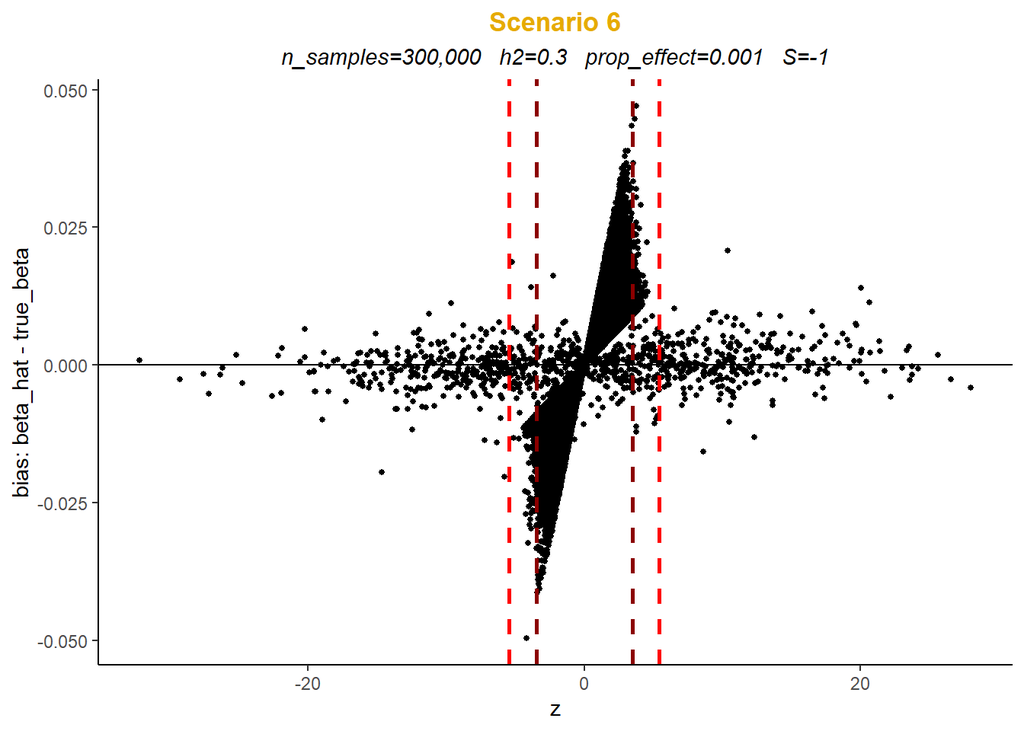

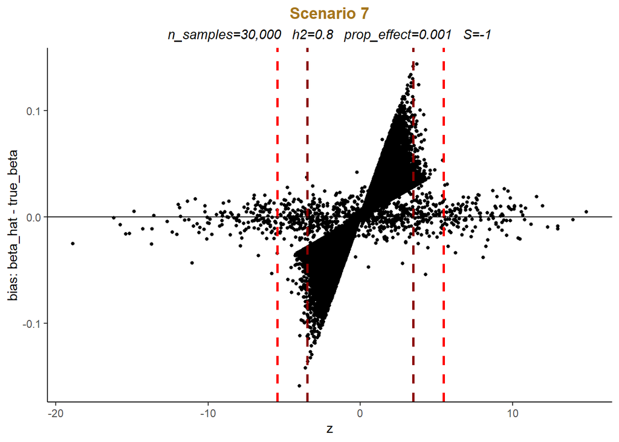

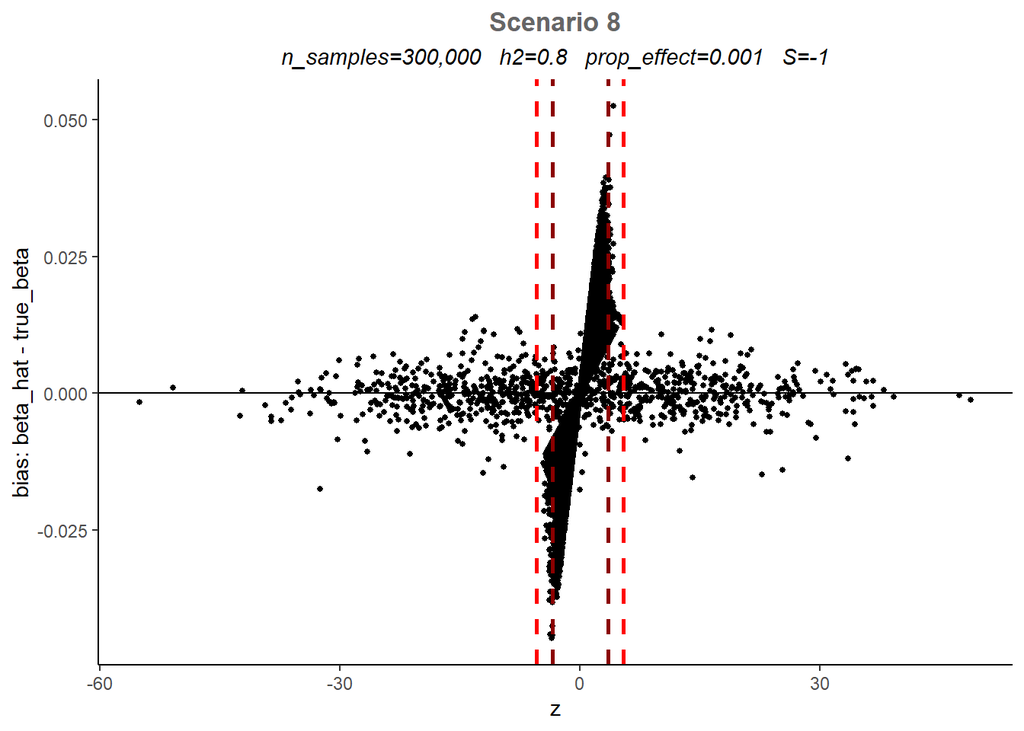

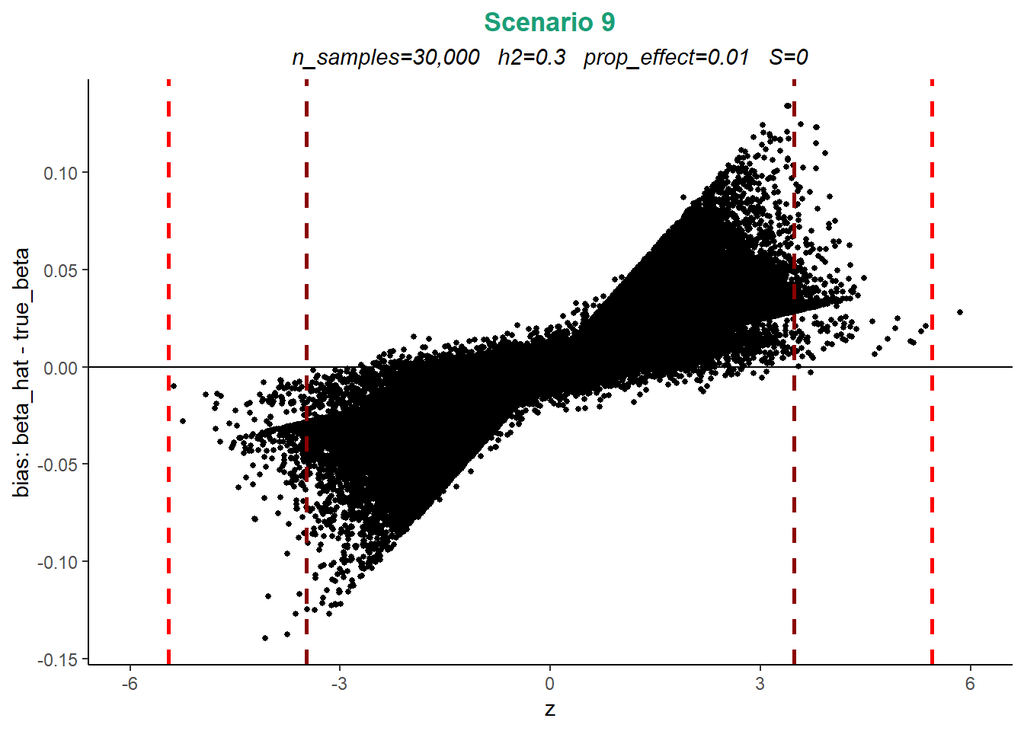

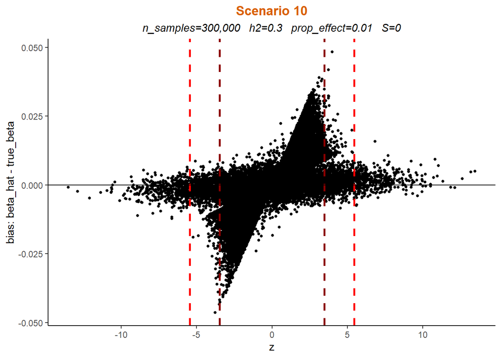

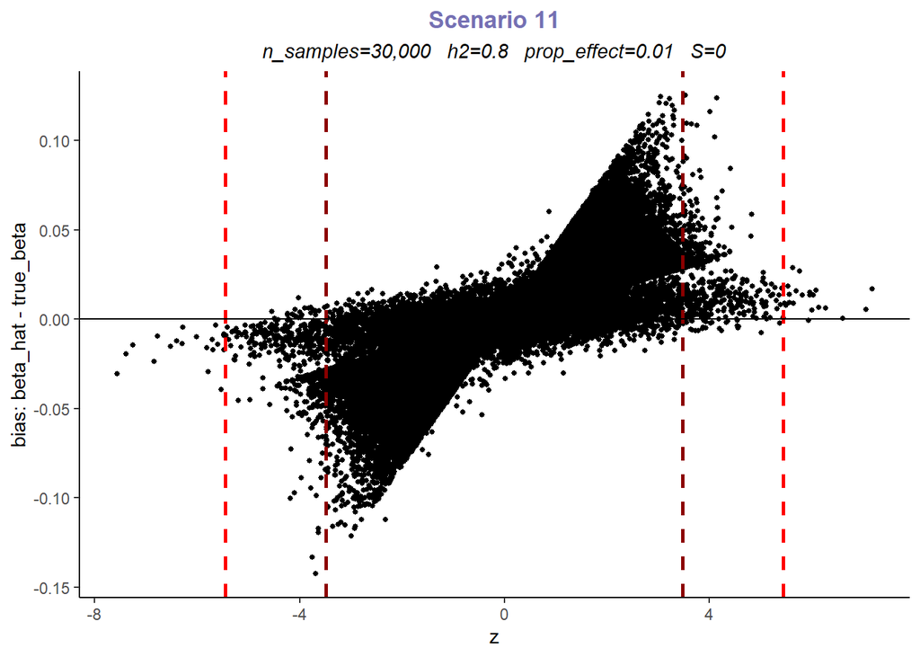

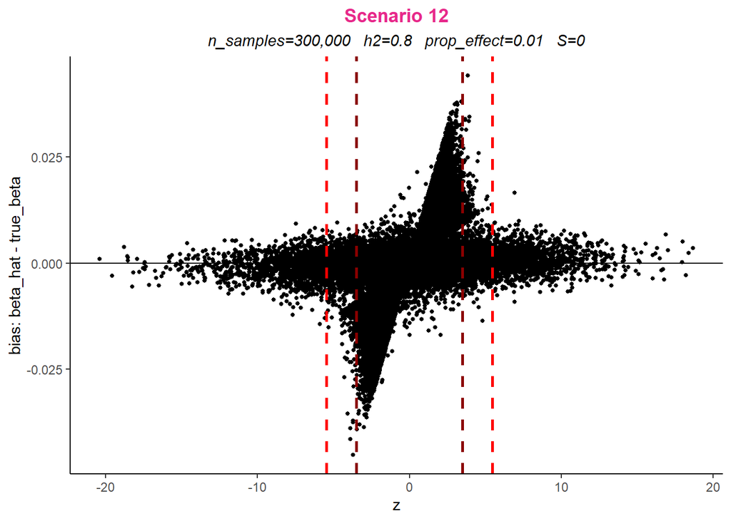

[12 more figures not shown]

### 2. Evaluating methods using a significance threshold of $5 \times 10^{-8}$

Using the code detailed in `norm_5e-8_10sim.R` and a total of 10 simulations, we evaluated six different Winner’s Curse methods across each of the 24 scenarios using the following three bias evaluation metrics:

1. The average fraction of significant SNPs in which their association estimates are *less* biased due to method implementation
2. The average change in average MSE of significant SNPs due to method implementation
3. The average *relative* change in average MSE of significant SNPs due to method implementation

**Note:** All averages were obtained over only those simulations in which at least one significant SNP was detected.

The average MSE over $n$ significant SNPs is defined as:
$$\frac{1}{n} \sum^n_{i=1} (\hat\beta_i - \beta_i)^2$$
in which $\mid \frac{\hat\beta_i}{\hat\sigma_i} \mid > c$ for all $i = 1,...,n$, where $\hat\beta_i$ is the estimated effect size of SNP $i$ and $\beta_i$ is its true effect size.

Results of the simulations are plotted with error bars included. These figures allow us to see more clearly the scenarios in which it would be beneficial to apply a Winner’s Curse correction method and also, provide us with a better indication of which method we should use.

Summary of results contained in `norm_5e-8_flb_10sim.csv`:

| Scenario | n_samples | h2 | prop_effect | S | EB | FIQT | BR | cl1 | cl2 | cl3 |
| --- | --- | --- | --- | --- | --- | --- | --- | --- | --- | --- |
| 1 | 30,000 | 0.3 | 0.010 | -1 | 1.0000 | 1.0000 | 1.0000 | 0.9444 | 1.0000 | 0.9375 |
| 2 | 300,000 | 0.3 | 0.010 | -1 | 0.6465 | 0.4422 | 0.6078 | 0.5290 | 0.4960 | 0.5038 |
| 3 | 30,000 | 0.8 | 0.010 | -1 | 0.8838 | 0.7446 | 0.7949 | 0.6342 | 0.7587 | 0.6466 |
| 4 | 300,000 | 0.8 | 0.010 | -1 | 0.5681 | 0.2803 | 0.5299 | 0.5149 | 0.4820 | 0.4972 |
| 5 | 30,000 | 0.3 | 0.001 | -1 | 0.6840 | 0.3621 | 0.5192 | 0.5419 | 0.5184 | 0.4950 |
| 6 | 300,000 | 0.3 | 0.001 | -1 | 0.4882 | 0.1447 | 0.3583 | 0.5031 | 0.4694 | 0.5014 |
| 7 | 30,000 | 0.8 | 0.001 | -1 | 0.5195 | 0.2095 | 0.3674 | 0.5085 | 0.4884 | 0.4802 |
| 8 | 300,000 | 0.8 | 0.001 | -1 | 0.4703 | 0.1016 | 0.3837 | 0.5137 | 0.4776 | 0.4895 |
| 9 | 30,000 | 0.3 | 0.010 | 0 | 0.8889 | 1.0000 | 0.9238 | 0.9333 | 0.9667 | 1.0000 |
| 10 | 300,000 | 0.3 | 0.010 | 0 | 0.6178 | 0.4004 | 0.5795 | 0.5233 | 0.4918 | 0.5167 |
| 11 | 30,000 | 0.8 | 0.010 | 0 | 0.8420 | 0.6658 | 0.7481 | 0.6007 | 0.6602 | 0.6383 |
| 12 | 300,000 | 0.8 | 0.010 | 0 | 0.5568 | 0.2688 | 0.5268 | 0.5125 | 0.4900 | 0.4962 |
| 13 | 30,000 | 0.3 | 0.001 | 0 | 0.6267 | 0.3232 | 0.4617 | 0.5343 | 0.5243 | 0.5299 |
| 14 | 300,000 | 0.3 | 0.001 | 0 | 0.4802 | 0.1446 | 0.3471 | 0.5164 | 0.4747 | 0.4871 |
| 15 | 30,000 | 0.8 | 0.001 | 0 | 0.5025 | 0.2091 | 0.3321 | 0.5143 | 0.4823 | 0.4997 |
| 16 | 300,000 | 0.8 | 0.001 | 0 | 0.4821 | 0.1072 | 0.4004 | 0.4994 | 0.4633 | 0.4795 |
| 17 | 30,000 | 0.3 | 0.010 | 1 | 0.8021 | 0.8883 | 0.8020 | 0.7852 | 0.9000 | 0.8520 |
| 18 | 300,000 | 0.3 | 0.010 | 1 | 0.6089 | 0.3625 | 0.5512 | 0.5336 | 0.4908 | 0.5006 |
| 19 | 30,000 | 0.8 | 0.010 | 1 | 0.8150 | 0.5901 | 0.6627 | 0.5702 | 0.6126 | 0.5875 |
| 20 | 300,000 | 0.8 | 0.010 | 1 | 0.5501 | 0.2605 | 0.5147 | 0.5152 | 0.4774 | 0.4970 |
| 21 | 30,000 | 0.3 | 0.001 | 1 | 0.5419 | 0.2678 | 0.4119 | 0.5413 | 0.4798 | 0.5144 |
| 22 | 300,000 | 0.3 | 0.001 | 1 | 0.4867 | 0.1301 | 0.3502 | 0.5046 | 0.4911 | 0.4994 |
| 23 | 30,000 | 0.8 | 0.001 | 1 | 0.4988 | 0.1816 | 0.3266 | 0.4995 | 0.4768 | 0.5032 |
| 24 | 300,000 | 0.8 | 0.001 | 1 | 0.4588 | 0.1123 | 0.3954 | 0.4999 | 0.4603 | 0.4911 |

$~$ $~$ $~$ $~$

**Fraction of significant SNPs** *less* **biased due to method implementation, using a significance threshold of $5 \times 10^{-8}$:**

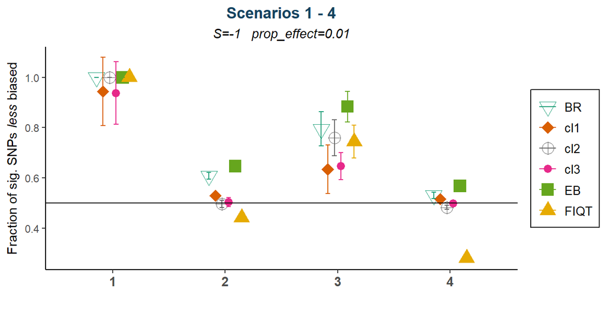

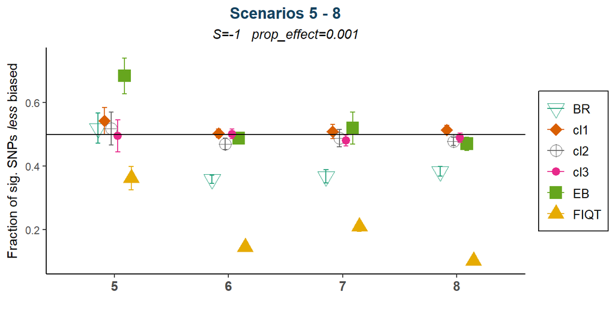

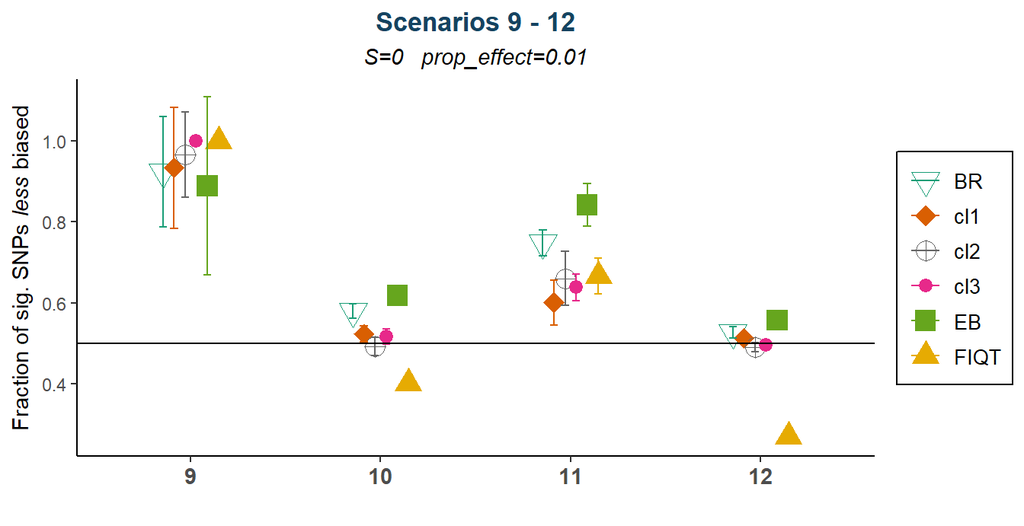

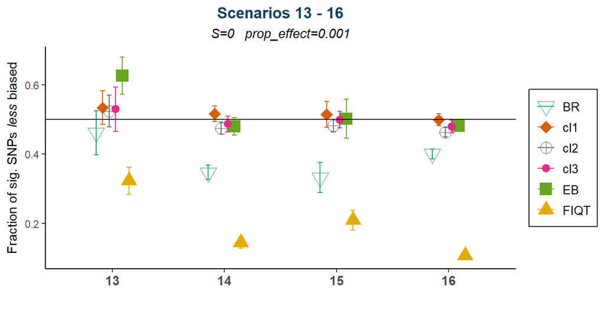

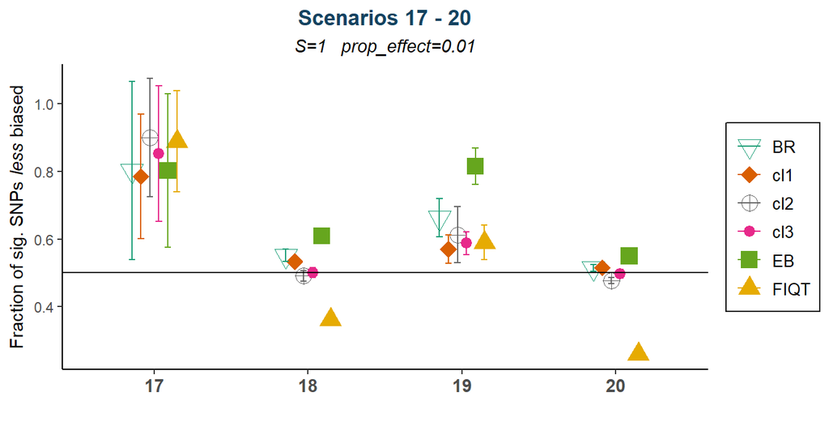

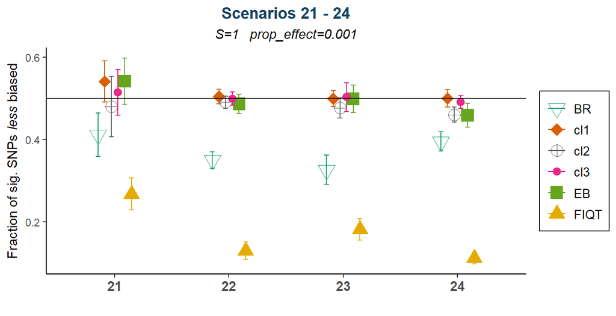

$~$ $~$ $~$ $~$

Summary of results contained in `norm_5e-8_mse-change2_10sim.csv`:

| Scenario | n_samples | h2 | prop_effect | S | EB | FIQT | BR | cl1 | cl2 | cl3 |
| --- | --- | --- | --- | --- | --- | --- | --- | --- | --- | --- |
| 1 | 30,000 | 0.3 | 0.010 | -1 | -0.002070 | -0.001182 | -0.000615 | -0.000895 | -0.001887 | -0.001006 |
| 2 | 300,000 | 0.3 | 0.010 | -1 | -0.000007 | 0.000002 | -0.000004 | 0.000053 | 0.000022 | 0.000036 |
| 3 | 30,000 | 0.8 | 0.010 | -1 | -0.000425 | -0.000376 | -0.000425 | 0.000271 | -0.000300 | -0.000058 |
| 4 | 300,000 | 0.8 | 0.010 | -1 | -0.000002 | 0.000005 | 0.000000 | 0.000034 | 0.000020 | 0.000027 |
| 5 | 30,000 | 0.3 | 0.001 | -1 | -0.000058 | 0.000118 | 0.000058 | 0.000450 | 0.000223 | 0.000433 |
| 6 | 300,000 | 0.3 | 0.001 | -1 | 0.000000 | 0.000006 | 0.000013 | 0.000013 | 0.000010 | 0.000013 |
| 7 | 30,000 | 0.8 | 0.001 | -1 | 0.000014 | 0.000106 | 0.000171 | 0.000335 | 0.000226 | 0.000267 |
| 8 | 300,000 | 0.8 | 0.001 | -1 | 0.000001 | 0.000003 | 0.000007 | 0.000009 | 0.000025 | 0.000015 |
| 9 | 30,000 | 0.3 | 0.010 | 0 | -0.000450 | -0.002613 | -0.000263 | -0.000197 | -0.000661 | -0.001975 |
| 10 | 300,000 | 0.3 | 0.010 | 0 | -0.000003 | 0.000000 | -0.000002 | 0.000026 | 0.000011 | 0.000019 |
| 11 | 30,000 | 0.8 | 0.010 | 0 | -0.000169 | -0.000117 | -0.000156 | 0.000211 | -0.000043 | 0.000016 |
| 12 | 300,000 | 0.8 | 0.010 | 0 | -0.000001 | 0.000002 | 0.000000 | 0.000021 | 0.000011 | 0.000015 |
| 13 | 30,000 | 0.3 | 0.001 | 0 | -0.000024 | 0.000067 | 0.000039 | 0.000265 | 0.000110 | 0.000167 |
| 14 | 300,000 | 0.3 | 0.001 | 0 | 0.000001 | 0.000004 | 0.000010 | 0.000014 | 0.000009 | 0.000010 |
| 15 | 30,000 | 0.8 | 0.001 | 0 | -0.000001 | 0.000067 | 0.000131 | 0.000223 | 0.000124 | 0.000145 |
| 16 | 300,000 | 0.8 | 0.001 | 0 | 0.000002 | 0.000004 | 0.000007 | 0.000010 | 0.000024 | 0.000013 |
| 17 | 30,000 | 0.3 | 0.010 | 1 | -0.000415 | -0.000407 | -0.000476 | -0.000226 | -0.000393 | -0.000387 |
| 18 | 300,000 | 0.3 | 0.010 | 1 | -0.000002 | 0.000002 | 0.000000 | 0.000022 | 0.000012 | 0.000016 |
| 19 | 30,000 | 0.8 | 0.010 | 1 | -0.000106 | -0.000105 | -0.000103 | 0.000251 | 0.000017 | 0.000080 |
| 20 | 300,000 | 0.8 | 0.010 | 1 | -0.000001 | 0.000002 | 0.000000 | 0.000017 | 0.000009 | 0.000012 |
| 21 | 30,000 | 0.3 | 0.001 | 1 | -0.000009 | 0.000071 | 0.000042 | 0.000194 | 0.000102 | 0.000168 |
| 22 | 300,000 | 0.3 | 0.001 | 1 | 0.000001 | 0.000004 | 0.000008 | 0.000011 | 0.000007 | 0.000009 |
| 23 | 30,000 | 0.8 | 0.001 | 1 | -0.000001 | 0.000053 | 0.000124 | 0.000164 | 0.000079 | 0.000119 |
| 24 | 300,000 | 0.8 | 0.001 | 1 | 0.000002 | 0.000003 | 0.000005 | 0.000007 | 0.000043 | 0.000019 |

$~$ $~$ $~$ $~$

*Change* **in average MSE over all significant SNPs due to method implementation, using a significance threshold of $5 \times 10^{-8}$:**

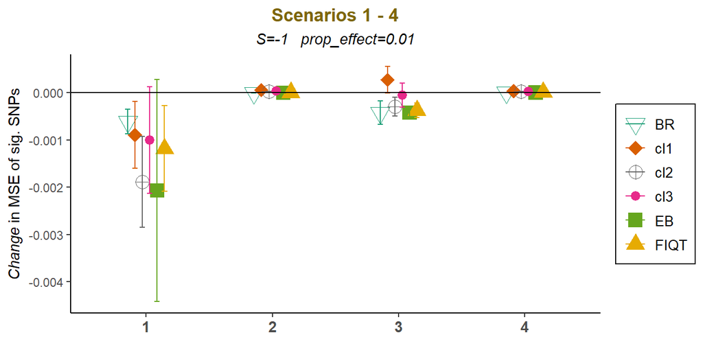

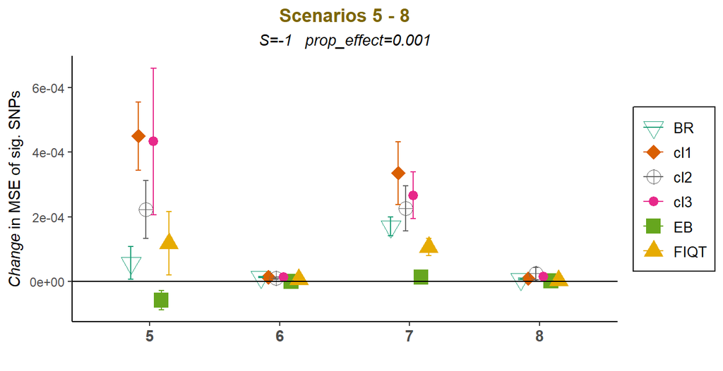

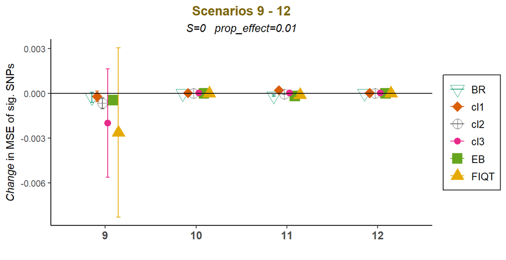

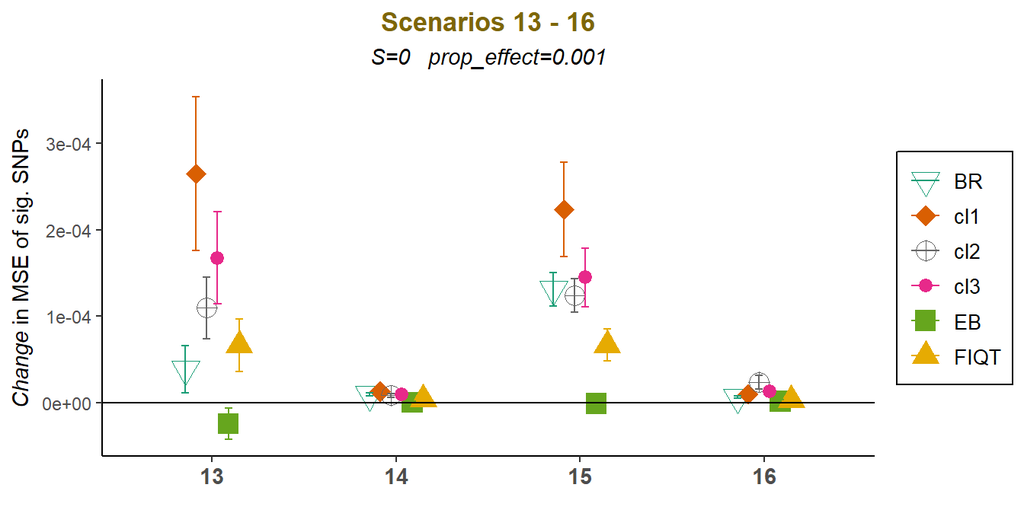

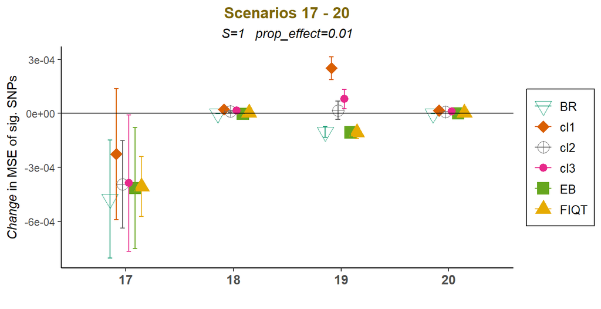

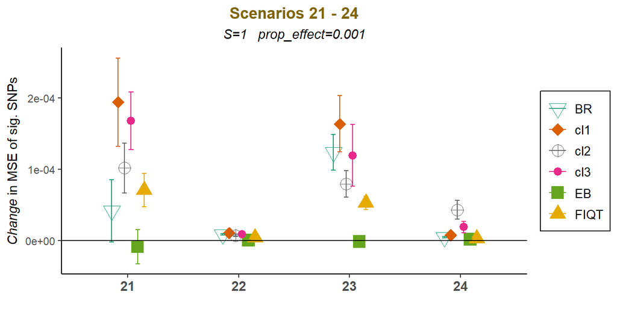

$~$ $~$ $~$ $~$

Summary of results contained in `norm_5e-8_mse-change_10sim.csv`:

| Scenario | n_samples | h2 | prop_effect | S | EB | FIQT | BR | cl1 | cl2 | cl3 |
| --- | --- | --- | --- | --- | --- | --- | --- | --- | --- | --- |
| 1 | 30,000 | 0.3 | 0.010 | -1 | -0.2790 | -0.3746 | -0.4888 | -0.0375 | -0.6638 | -0.4246 |
| 2 | 300,000 | 0.3 | 0.010 | -1 | -0.3203 | 0.0175 | -0.2250 | 2.6836 | 1.0236 | 1.5283 |
| 3 | 30,000 | 0.8 | 0.010 | -1 | -0.6762 | -0.8032 | -0.7688 | 0.4359 | -0.4902 | -0.1540 |
| 4 | 300,000 | 0.8 | 0.010 | -1 | -0.0887 | 0.2997 | 0.0047 | 1.9750 | 1.1278 | 1.4642 |
| 5 | 30,000 | 0.3 | 0.001 | -1 | -0.2628 | 0.6090 | 0.2191 | 3.6710 | 0.9562 | 1.2863 |
| 6 | 300,000 | 0.3 | 0.001 | -1 | 0.0461 | 0.4218 | 0.9426 | 0.9694 | 0.6575 | 0.7537 |
| 7 | 30,000 | 0.8 | 0.001 | -1 | 0.0277 | 0.8386 | 0.9865 | 1.9543 | 1.2192 | 1.6268 |
| 8 | 300,000 | 0.8 | 0.001 | -1 | 0.0703 | 0.2036 | 0.4137 | 0.6165 | 1.4676 | 0.6500 |
| 9 | 30,000 | 0.3 | 0.010 | 0 | -0.6510 | -0.7090 | -0.6114 | -0.1210 | -0.4323 | -0.5700 |
| 10 | 300,000 | 0.3 | 0.010 | 0 | -0.2865 | 0.0660 | -0.1810 | 2.1525 | 1.0570 | 1.5284 |
| 11 | 30,000 | 0.8 | 0.010 | 0 | -0.6611 | -0.5806 | -0.6618 | 1.1235 | -0.2887 | 0.2525 |
| 12 | 300,000 | 0.8 | 0.010 | 0 | -0.1029 | 0.2029 | -0.0318 | 2.0116 | 1.0700 | 1.4572 |
| 13 | 30,000 | 0.3 | 0.001 | 0 | -0.2009 | 0.7957 | 0.3071 | 2.5368 | 0.9833 | 1.6376 |
| 14 | 300,000 | 0.3 | 0.001 | 0 | 0.0535 | 0.4545 | 0.8911 | 1.3077 | 0.7226 | 0.9414 |
| 15 | 30,000 | 0.8 | 0.001 | 0 | -0.0067 | 0.6215 | 0.9349 | 2.1777 | 1.2103 | 1.6674 |
| 16 | 300,000 | 0.8 | 0.001 | 0 | 0.1373 | 0.3316 | 0.4154 | 0.7637 | 2.0854 | 1.1382 |
| 17 | 30,000 | 0.3 | 0.010 | 1 | -0.6691 | -0.5763 | -0.6516 | 0.2659 | -0.8541 | 3.4418 |
| 18 | 300,000 | 0.3 | 0.010 | 1 | -0.2115 | 0.2017 | -0.0248 | 2.3109 | 1.1186 | 1.5671 |
| 19 | 30,000 | 0.8 | 0.010 | 1 | -0.6191 | -0.4023 | -0.4801 | 1.2340 | -0.0312 | 0.6310 |
| 20 | 300,000 | 0.8 | 0.010 | 1 | -0.0730 | 0.2276 | 0.0080 | 1.8310 | 1.0043 | 1.3454 |
| 21 | 30,000 | 0.3 | 0.001 | 1 | -0.1434 | 0.6273 | 0.4781 | 2.4055 | 1.0646 | 1.4649 |
| 22 | 300,000 | 0.3 | 0.001 | 1 | 0.0446 | 0.3751 | 0.9598 | 1.2718 | 0.6395 | 0.7813 |
| 23 | 30,000 | 0.8 | 0.001 | 1 | 0.0154 | 0.6661 | 1.4321 | 1.7884 | 1.0911 | 1.3269 |
| 24 | 300,000 | 0.8 | 0.001 | 1 | 0.1938 | 0.2325 | 0.4878 | 0.8037 | 4.3754 | 1.4777 |

$~$ $~$ $~$ $~$

*Relative change* **in average MSE over all significant SNPs due to method implementation, using a significance threshold of $5 \times 10^{-8}$:**

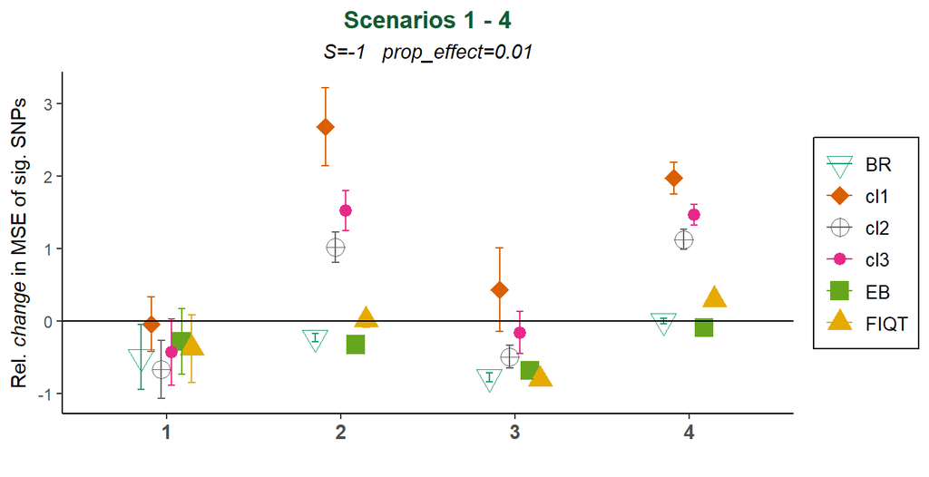

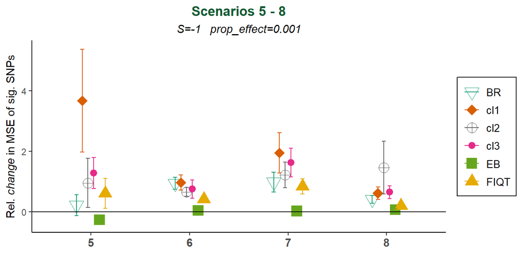

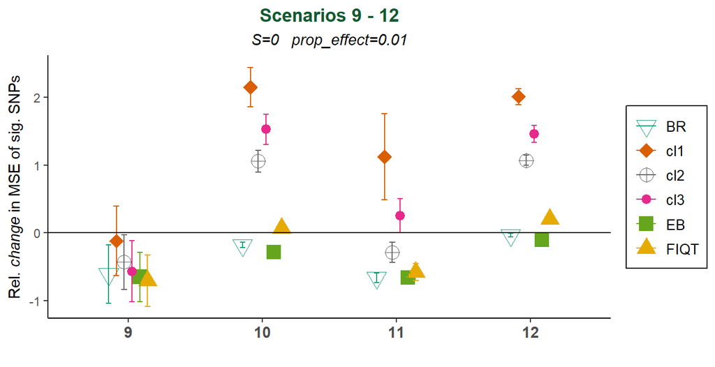

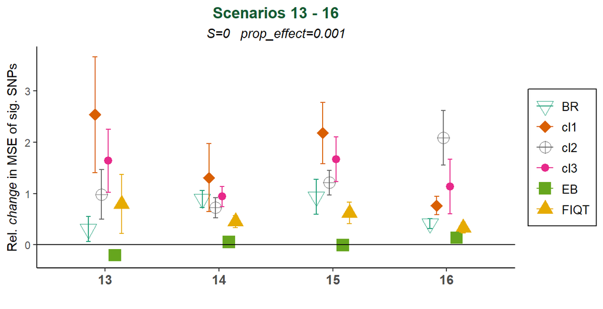

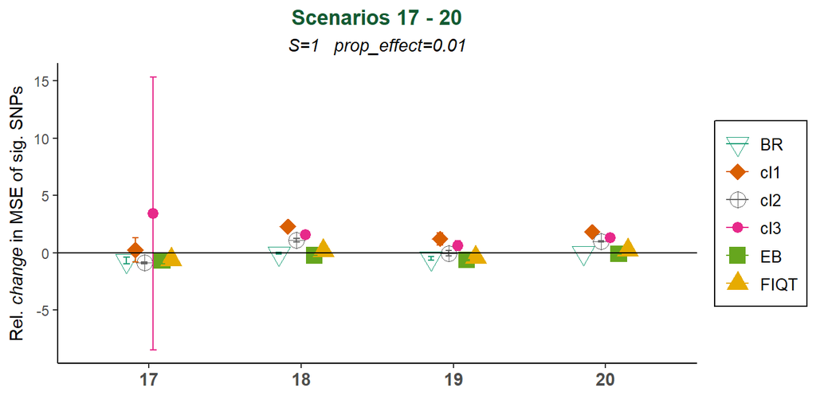

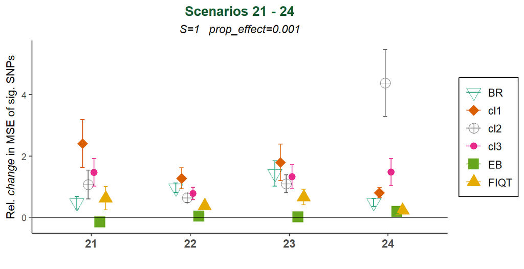